# Nat. Chem. Bio (2019)

## Figure 3

Goal is to determine how these modifications are distributed; thought it’d be interesting to visualize by average added mass (MA) to a protein, with several small changes in molecular mass, with some very large additions of mass

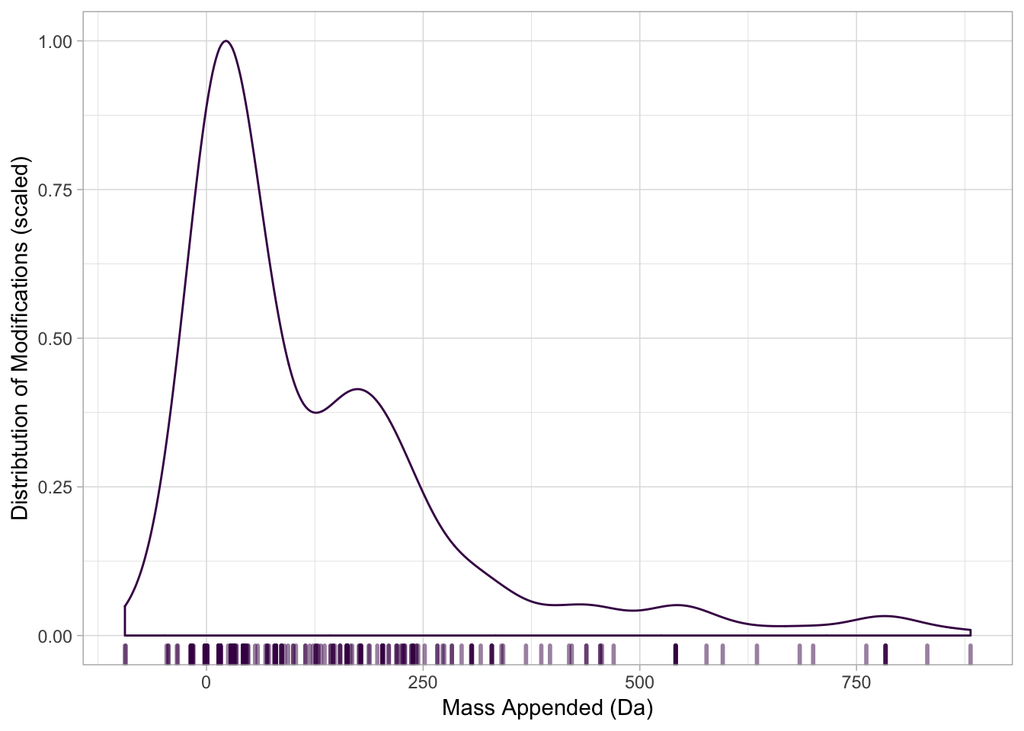

```r
ptm %>%
  filter(!FT == "CROSSLNK") %>% #omit AA cross links only
  ggplot() +
  #geom_point(aes(x = MA, y =0, color = fct_lump(KW, 0)), shape = "|", size = 15, alpha = 1/2) +
  geom_density(aes(x = MA, ..scaled.., color = fct_lump(KW,0))) +
  geom_rug(aes(x = MA, y = 0, color = fct_lump(KW,0)), sides = "b", alpha = 1/2, position = "jitter", size = 1) +
  labs(x = "Mass Appended (Da)", y = "Distribtution of Modifications (scaled)") +
  scale_color_viridis(discrete = TRUE, direction = 1) +
  scale_y_continuous(limits = c(0,1)) +
  theme(legend.position = "") +
  NULL
```

```r
#save plot
ggsave("output/fig3.pdf", plot = last_plot(), width = 5, height = 5, dpi = 600)
#the reason some average masses (MA) are so abundant is because you find the same modifications across several AAs, thereby weighting some more
#NB several glycans and lipids are variable masses, and therefore are entered as NA, so not reflected in the graph

ptm %>%
  filter(!FT == "CROSSLNK") %>% #omit AA cross links only
  count(KW, sort = TRUE)
```

| KW | n |
| --- | --- |
| Glycoprotein | 93 |
| Other | 80 |
| Methylation | 50 |
| Hydroxylation | 45 |
| Amidation | 20 |
| Acetylation | 16 |
| Glycoprotein; Hydroxylation | 16 |
| Phosphoprotein | 15 |
| Lipoprotein | 14 |
| GPI-anchor | 13 |

[output cut: 40 more lines]

### Lysine Analysis

In this code chunk, the goal is to count and summarize lysine modifications.

```r
ptm %>%
  filter(!FT == "CROSSLNK") %>% #omit AA cross links only
  filter(TG == "Lysine") %>%
  count(ID, sort = TRUE)
```

| ID | n |
| --- | --- |
| (3S)-3-hydroxylysine | 1 |
| (5R)-5-hydroxylysine | 1 |
| (5S)-5-hydroxylysine | 1 |
| 4-hydroxylysine | 1 |
| 4,5-dihydroxylysine | 1 |
| 5-hydroxylysine | 1 |
| Allysine | 1 |
| Hypusine | 1 |
| Lysine amide | 1 |
| Lysine derivative | 1 |

[output cut: 37 more lines]

```r
#code chunk to make a tibble that is easy to view all attributes; no need to save as an object in environment
ptm %>%
  filter(!FT == "CROSSLNK") %>% #omit AA cross links only
  filter(TG == "Lysine") %>%
  arrange(MA) #sorts by mass, low to high
```

| id | AC | CF | FT | ID | KW | LC | MA | MM | PA | PP | TG |
| --- | --- | --- | --- | --- | --- | --- | --- | --- | --- | --- | --- |
| Allysine | PTM-0059 | H-3 N-1 O1 | MOD_RES | Allysine | Other | Extracellular and lumenal localisation. | -1.03 | -1.031634 | Amino acid side chain. | Anywhere. | Lysine |
| Lysine amide | PTM-0168 | H1 N1 O-1 | MOD_RES | Lysine amide | Amidation | Extracellular and lumenal localisation. | -0.98 | -0.984016 | Amino acid backbone. | C-terminal. | Lysine |
| Lysine methyl ester | PTM-0170 | C1 H2 | MOD_RES | Lysine methyl ester | Methylation | Intracellular localisation. | 14.03 | 14.015650 | Amino acid backbone. | C-terminal. | Lysine |
| N6-methyllysine | PTM-0194 | C1 H2 | MOD_RES | N6-methyllysine | Methylation | Intracellular localisation. | 14.03 | 14.015650 | Amino acid side chain. | Anywhere. | Lysine |
| (3S)-3-hydroxylysine | PTM-0663 | O1 | MOD_RES | (3S)-3-hydroxylysine | Hydroxylation | Extracellular and lumenal localisation. | 16.00 | 15.994915 | Amino acid side chain. | Anywhere. | Lysine |
| (5R)-5-hydroxylysine | PTM-0471 | O1 | MOD_RES | (5R)-5-hydroxylysine | Hydroxylation | Extracellular and lumenal localisation. | 16.00 | 15.994915 | Amino acid side chain. | Anywhere. | Lysine |
| (5S)-5-hydroxylysine | PTM-0472 | O1 | MOD_RES | (5S)-5-hydroxylysine | Hydroxylation | Extracellular and lumenal localisation. | 16.00 | 15.994915 | Amino acid side chain. | Anywhere. | Lysine |
| 4-hydroxylysine | PTM-0664 | O1 | MOD_RES | 4-hydroxylysine | Hydroxylation | Extracellular and lumenal localisation. | 16.00 | 15.994915 | Amino acid side chain. | Anywhere. | Lysine |
| 5-hydroxylysine | PTM-0044 | O1 | MOD_RES | 5-hydroxylysine | Hydroxylation | Extracellular and lumenal localisation. | 16.00 | 15.994915 | Amino acid side chain. | Anywhere. | Lysine |
| N6-formyllysine | PTM-0192 | C1 O1 | MOD_RES | N6-formyllysine | Formylation | Extracellular and lumenal localisation. | 28.01 | 27.994915 | Amino acid side chain. | Anywhere. | Lysine |

[output cut: 37 more lines]

## Figure 4

In this figure, the goal is to determine how many acyl-CoA species have been measured

```r
#reload
load("data/proteins_raw.Rda")
load("data/metabolites_raw.Rda")
```

```r
#as.X
proteins_raw <- as_tibble(proteins_raw)
metabolites_raw <- as_tibble(metabolites_raw)
metabolites_raw$average_molecular_weight <- as.numeric(metabolites_raw$average_molecular_weight)

#clean
metabolites <- metabolites_raw %>%
  select(one_of("accession", "name", "average_molecular_weight", "chemical_formula", "smiles", "normal_concentrations")) %>%
  clean_names() %>%
  remove_empty("rows")
```

```r
#count CoAs
CoA <- metabolites %>%
  filter(str_detect(name, "CoA")) %>%
  mutate(average_molecular_weight_noCoA = round(average_molecular_weight - 767.534, 2)) %>%  #substract weight of CoA for appended mass
  arrange(average_molecular_weight_noCoA)

CoA <- CoA %>% #number of carbons
  mutate(carbon_num = str_extract(chemical_formula, "C\\d+")) %>% #extract C then digit, then one or more
  mutate(carbon_num = str_extract(carbon_num, "\\d+")) %>% #to extract digit only
  mutate(carbon_num = as.numeric(carbon_num)) %>% #numeric, to do substraction next
  mutate(carbon_num_acyl = carbon_num - 21) %>% #remove number of carbons in CoA alone, to get acyls
  slice(-1:-6) %>%  #typos in the dataset
  arrange(carbon_num_acyl) %>%
  mutate (type = "CoA")

CoA <- CoA %>% #number of oxygens
  mutate(o2_num = str_extract(chemical_formula, "O\\d+")) %>% #extract C then digit, then one or more
  mutate(o2_num = str_extract(o2_num, "\\d+")) %>% #to extract digit only
  mutate(o2_num = as.numeric(o2_num)) %>% #numeric, to do substraction next
  mutate(o2_num_acyl = o2_num - 16) %>% #remove number of oxygens in CoA alone, to get acyls
  slice(-1) #remove dephosphoCoA

CoA <- CoA %>%
  separate(smiles, into = c("smiles1", "smiles2"), sep = "S", remove = FALSE, extra = "merge") #split smiles code on the Sulfur(S); needed to split this from the next code chunk, so it runs first; if not, then throws an error that 'smiles1' does not exist (length is zero)
#https://en.wikipedia.org/wiki/Simplified_molecular-input_line-entry_system

CoA <- CoA %>%
  mutate(smiles_acyl = if_else(str_detect(smiles1, "P"), smiles2, smiles1)) #this is the code that pulls the 'acyl' from the split smiles data, and discards the CoA, becuase it contains the phosphate; this will allow me to look only at the possible protein appendage.

CoA <- CoA %>%
  mutate(acyl_description = if_else(str_detect(smiles_acyl, "\\(O\\)\\=O"), "Carboxyl",
                                    if_else(str_detect(smiles_acyl, "CO"), "Hydroxyl",
                                    if_else(str_detect(smiles_acyl, "C\\(O\\)C"), "Hydroxyl",
                                    if_else(str_detect(smiles_acyl, "C\\=C"), "Methylene",
                                    if_else(str_detect(smiles_acyl, "C\\(\\=C\\)"), "Methylene",
                                    if_else(str_detect(smiles_acyl, "CC\\=O"), "Aldehyde", #hardcode aldehyde
                                    if_else(str_detect(smiles_acyl, "C\\=O"), "Straight", #hardcode formyl
                                    if_else(str_detect(smiles_acyl, "C\\(C\\)"), "Branched",
                                    if_else(str_detect(smiles_acyl, "CCC"), "Straight",
                                    if_else(str_detect(smiles_acyl, "CC\\(\\=O\\)"), "Straight", #hardcode acetyl
                                        "Other")))))))))))

CoA %>%
  filter(str_detect(smiles_acyl, "N")) %>% #looking
  count(smiles_acyl, sort = TRUE)
```

| smiles_acyl | n |
| --- | --- |
| [H][C@](O)(C(O)=NCCC(O)=NCC | 6 |
| [H][C@](O)(C(=O)NCCC(=O)NCC | 3 |
| C(=O)C=CCCC=CCC=CC=CC=CC(SCC(N)C(O)=O)C(O)CCCC(O)=O | 1 |
| C(=O)C=CCCCC=CC=CC=CC(SCC(N)C(O)=O)C(O)CCCC(O)=O | 1 |
| C(=O)CC(=O)CCC=CCC=CC=CC=CC(SCC(N)C(O)=O)C(O)CCCC(O)=O | 1 |
| C(=O)CC(=O)CCCC=CC=CC=CC(SCC(N)C(O)=O)C(O)CCCC(O)=O | 1 |
| C(=O)CC(O)CCC=CCC=CC=CC=CC(SCC(N)C(O)=O)C(O)CCCC(O)=O | 1 |
| C(=O)CC(O)CCCC=CC=CC=CC(SCC(N)C(O)=O)C(O)CCCC(O)=O | 1 |
| C(=O)CC=CC=CC=CC=CC(SCC(N)C(O)=O)C(O)CCCC(O)=O | 1 |
| C(=O)CC=CCCC=CC=CC=CC(SCC(N)C(O)=O)C(O)CCCC(O)=O | 1 |

[output cut: 6 more lines]

```r
CoA %>%
  count(average_molecular_weight, sort = TRUE) #code chunk to count acyl-CoAs, both total and discrete Molecular Weights
```

| average_molecular_weight | n |
| --- | --- |
| 1124.076 | 8 |
| 891.714 | 5 |
| 851.651 | 4 |
| 867.607 | 4 |
| 917.752 | 4 |
| 919.768 | 4 |
| 963.820 | 4 |
| 1031.980 | 4 |
| 1106.060 | 4 |
| 1122.060 | 4 |

[output cut: 224 more lines]

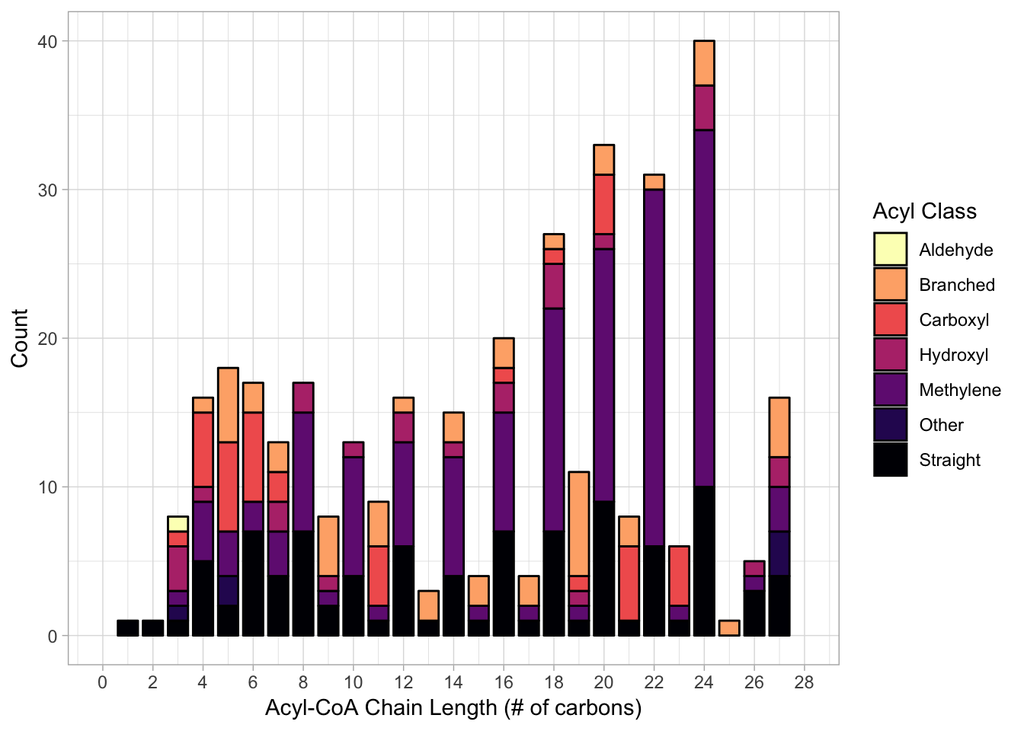

```r
ggplot(CoA) +
  geom_bar(aes(x = carbon_num_acyl, fill = acyl_description), color = "black", width = 0.8) +
  labs(x = "Acyl-CoA Chain Length (# of carbons)", y = "Count") +
  expand_limits(y = 40) +
  scale_fill_viridis(discrete = TRUE, direction = -1, option = "magma", name = "Acyl Class") +
  scale_x_continuous(breaks = c(0,2,4,6,8,10,12,14,16,18,20,22,24,26,28), limits = c(0,28)) +
  NULL
```

```r
#save plot
ggsave("output/fig4.pdf", plot = last_plot(), width = 5, height = 5, dpi = 600)

CoA %>%
  count(average_molecular_weight_noCoA, sort = TRUE)
```

| average_molecular_weight_noCoA | n |
| --- | --- |
| 356.54 | 8 |
| 124.18 | 5 |
| 84.12 | 4 |
| 100.07 | 4 |
| 150.22 | 4 |
| 152.23 | 4 |
| 180.29 | 4 |
| 196.29 | 4 |
| 264.45 | 4 |
| 338.53 | 4 |

[output cut: 221 more lines]

### Cysteine Analysis

In this code chunk, the goal is to count and summarize cysteine modifications. Counted 57 (as of Feb 2019), however does not include 3 published modifiations: succination, 2,3-dicarboxylpropylation (i.e. itaconylation), or s-acetylation, so OK to conclude 60, at least.

```r
ptm %>%
  filter(!FT == "CROSSLNK") %>% #omit AA cross links only
  filter(TG == "Cysteine") %>%
  count(ID, sort = TRUE)
```

| ID | n |
| --- | --- |
| 2-(S-cysteinyl)pyruvic acid O-phosphothioketal | 1 |
| 2,3-didehydroalanine (Cys) | 1 |
| 3-oxoalanine (Cys) | 1 |
| ADP-ribosylcysteine | 1 |
| Blocked amino end (Cys) | 1 |
| Cyclo[(prolylserin)-O-yl] cysteinate | 1 |
| Cysteine amide | 1 |
| Cysteine derivative | 1 |
| Cysteine methyl disulfide | 1 |
| Cysteine methyl ester | 1 |

[output cut: 47 more lines]

```r
#code chunk to make a tibble that is easy to view all attributes; no need to save as an object in environment
ptm %>%
  filter(!FT == "CROSSLNK") %>% #omit AA cross links only
  filter(TG == "Cysteine") %>%
  arrange(MA) #sorts by mass, low to high
```

| id | AC | CF | FT | ID | KW | LC | MA | MM | PA | PP | TG |
| --- | --- | --- | --- | --- | --- | --- | --- | --- | --- | --- | --- |
| 2,3-didehydroalanine (Cys) | PTM-0468 | H-2 S-1 | MOD_RES | 2,3-didehydroalanine (Cys) | Other | Intracellular localisation. | -34.08 | -33.987721 | Amino acid backbone. | Protein core. | Cysteine |
| Pyruvic acid (Cys) | PTM-0265 | H-3 N-1 O1 S-1 | MOD_RES | Pyruvic acid (Cys) | Pyruvate | Intracellular localisation. | -33.09 | -33.003705 | Amino acid backbone. | N-terminal. | Cysteine |
| 3-oxoalanine (Cys) | PTM-0033 | H-2 O1 S-1 | MOD_RES | 3-oxoalanine (Cys) | Other | Extracellular and lumenal localisation. | -18.08 | -17.992806 | Amino acid side chain. | Anywhere. | Cysteine |
| D-serine (Cys) | PTM-0309 | O1 S-1 | MOD_RES | D-serine (Cys) | D-amino acid | Extracellular and lumenal localisation. | -16.06 | -15.977156 | Amino acid backbone. | Protein core. | Cysteine |
| Cysteine amide | PTM-0102 | H1 N1 O-1 | MOD_RES | Cysteine amide | Amidation | Extracellular and lumenal localisation. | -0.98 | -0.984016 | Amino acid backbone. | C-terminal. | Cysteine |
| Cysteine methyl ester | PTM-0105 | C1 H2 | MOD_RES | Cysteine methyl ester | Methylation | Intracellular localisation. | 14.03 | 14.015650 | Amino acid backbone. | C-terminal. | Cysteine |
| S-methylcysteine | PTM-0279 | C1 H2 | MOD_RES | S-methylcysteine | Methylation | Intracellular localisation. | 14.03 | 14.015650 | Amino acid side chain. | Anywhere. | Cysteine |
| Cysteine sulfenic acid (-SOH) | PTM-0107 | O1 | MOD_RES | Cysteine sulfenic acid (-SOH) | Oxidation | Intracellular localisation. | 16.00 | 15.994915 | Amino acid side chain. | Anywhere. | Cysteine |
| S-cyanocysteine | PTM-0650 | C1 H-1 N1 | MOD_RES | S-cyanocysteine | Other | Intracellular localisation. | 25.01 | 24.995249 | Amino acid side chain. | Anywhere. | Cysteine |
| S-nitrosocysteine | PTM-0280 | H-1 N1 O1 | MOD_RES | S-nitrosocysteine | S-nitrosylation | Intracellular localisation. | 29.00 | 28.990164 | Amino acid side chain. | Anywhere. | Cysteine |

[output cut: 47 more lines]

### Serine Analysis

In this code chunk, the goal is to count and summarize serine modifications. Counted 70 (as of Feb 2019).

```r
ptm %>%
  filter(!FT == "CROSSLNK") %>% #omit AA cross links only
  filter(TG == "Serine") %>%
  count(ID, sort = TRUE)
```

| ID | n |
| --- | --- |
| 2,3-didehydroalanine (Ser) | 1 |
| 3-oxoalanine (Ser) | 1 |
| ADP-ribosylserine | 1 |
| Aminomalonic acid (Ser) | 1 |
| Blocked amino end (Ser) | 1 |
| D-alanine (Ser) | 1 |
| D-serine (Ser) | 1 |
| FMN phosphoryl serine | 1 |
| GPI-anchor amidated serine | 1 |
| GPI-like-anchor amidated serine | 1 |

[output cut: 60 more lines]

```r
ptm %>%
  filter(!FT == "CROSSLNK") %>% #omit AA cross links only
  filter(TG == "Threonine") %>%
  count(ID, sort = TRUE)
```

| ID | n |
| --- | --- |
| (E)-2,3-didehydrobutyrine | 1 |
| (Z)-2,3-didehydrobutyrine | 1 |
| 1-amino-2-propanone | 1 |
| 2-oxobutanoic acid | 1 |
| 2,3-didehydrobutyrine | 1 |
| Blocked amino end (Thr) | 1 |
| D-threonine | 1 |
| Decarboxylated threonine | 1 |
| FMN phosphoryl threonine | 1 |
| GPI-anchor amidated threonine | 1 |

[output cut: 33 more lines]

```r
ptm %>%
  filter(!FT == "CROSSLNK") %>% #omit AA cross links only
  filter(TG == "Tyrosine") %>%
  count(ID, sort = TRUE)
```

| ID | n |
| --- | --- |
| (E)-2,3-didehydrotyrosine | 1 |
| (Z)-2,3-didehydrotyrosine | 1 |
| 2,3-didehydroalanine (Tyr) | 1 |
| 2,3-didehydrotyrosine | 1 |
| 2',4',5'-topaquinone | 1 |
| 3'-nitrotyrosine | 1 |
| 3',4'-dihydroxyphenylalanine | 1 |
| 3',4',5'-trihydroxyphenylalanine | 1 |
| ADP-ribosyltyrosine | 1 |
| Diiodotyrosine | 1 |

[output cut: 25 more lines]

```r
ptm %>%
  filter(!FT == "CROSSLNK") %>% #omit AA cross links only
  filter(TG == "Serine") %>%
  filter(str_detect(CF, "P")) %>%
  count(ID, sort = TRUE)
```

| ID | n |
| --- | --- |
| ADP-ribosylserine | 1 |
| FMN phosphoryl serine | 1 |
| O-(2-aminoethylphosphoryl)serine | 1 |
| O-(2-cholinephosphoryl)serine | 1 |
| O-(pantetheine 4'-phosphoryl)serine | 1 |
| O-(phosphoribosyl dephospho-coenzyme A)serine | 1 |
| O-(sn-1-glycerophosphoryl)serine | 1 |
| O-AMP-serine | 1 |
| O-linked (GlcNAc1P) serine | 1 |
| O-linked (GlcNAc6P) serine | 1 |

[output cut: 3 more lines]

```r
#13 serine modifications contain phosphate (12 carbon-phosphate, 1 phosphate only)

#code chunk to make a tibble that is easy to view all attributes; no need to save as an object in environment
ptm %>%
  filter(!FT == "CROSSLNK") %>% #omit AA cross links only
  filter(TG == "Serine") %>%
  arrange(MA) #sorts by mass, low to high
```

| id | AC | CF | FT | ID | KW | LC | MA | MM | PA | PP | TG |
| --- | --- | --- | --- | --- | --- | --- | --- | --- | --- | --- | --- |
| 2,3-didehydroalanine (Ser) | PTM-0006 | H-2 O-1 | MOD_RES | 2,3-didehydroalanine (Ser) | Other | Intracellular localisation. | -18.02 | -18.010565 | Amino acid backbone. | Protein core. | Serine |
| Pyruvic acid (Ser) | PTM-0266 | H-3 N-1 | MOD_RES | Pyruvic acid (Ser) | Pyruvate | Intracellular localisation. | -17.03 | -17.026549 | Amino acid backbone. | N-terminal. | Serine |
| D-alanine (Ser) | PTM-0113 | O-1 | MOD_RES | D-alanine (Ser) | D-amino acid | Extracellular and lumenal localisation. | -16.00 | -15.994915 | Amino acid backbone. | Protein core. | Serine |
| Lactic acid | PTM-0163 | H-1 N-1 | MOD_RES | Lactic acid | Other | Extracellular and lumenal localisation. | -15.02 | -15.010899 | Amino acid backbone. | N-terminal. | Serine |
| 3-oxoalanine (Ser) | PTM-0034 | H-2 | MOD_RES | 3-oxoalanine (Ser) | Other | Extracellular and lumenal localisation. | -2.02 | -2.015650 | Amino acid side chain. | Anywhere. | Serine |
| Serine amide | PTM-0275 | H1 N1 O-1 | MOD_RES | Serine amide | Amidation | Extracellular and lumenal localisation. | -0.98 | -0.984016 | Amino acid backbone. | C-terminal. | Serine |
| Aminomalonic acid (Ser) | PTM-0321 | H-2 O1 | MOD_RES | Aminomalonic acid (Ser) | Other | Extracellular and lumenal localisation. | 13.98 | 13.979265 | Amino acid side chain. | Anywhere. | Serine |
| N-methylserine | PTM-0432 | C1 H2 | MOD_RES | N-methylserine | Methylation | Intracellular localisation. | 14.03 | 14.015650 | Amino acid backbone. | N-terminal. | Serine |
| N,N-dimethylserine | PTM-0431 | C2 H4 | MOD_RES | N,N-dimethylserine | Methylation | Intracellular localisation. | 28.05 | 28.031300 | Amino acid backbone. | N-terminal. | Serine |
| N-acetylserine | PTM-0207 | C2 H2 O1 | MOD_RES | N-acetylserine | Acetylation | Intracellular localisation. | 42.04 | 42.010565 | Amino acid backbone. | N-terminal. | Serine |

[output cut: 60 more lines]

### Phenylalanine Analysis

In this code chunk, the goal is to count and summarize phenylalanine modifications. Counted 5 (as of Feb 2019); 1?

```r
ptm %>%
  filter(!FT == "CROSSLNK") %>% #omit AA cross links only
  filter(TG == "Phenylalanine") %>%
  arrange(MA) #sorts by mass, low to high
```

| id | AC | CF | FT | ID | KW | LC | MA | MM | PA | PP | TG |
| --- | --- | --- | --- | --- | --- | --- | --- | --- | --- | --- | --- |
| Phenylalanine amide | PTM-0248 | H1 N1 O-1 | MOD_RES | Phenylalanine amide | Amidation | Extracellular and lumenal localisation. | -0.98 | -0.984016 | Amino acid backbone. | C-terminal. | Phenylalanine |
| 3-phenyllactic acid | PTM-0035 | H-1 N-1 O1 | MOD_RES | 3-phenyllactic acid | Other | Extracellular and lumenal localisation. | 0.98 | 0.984016 | Amino acid backbone. | N-terminal. | Phenylalanine |
| N-methylphenylalanine | PTM-0218 | C1 H2 | MOD_RES | N-methylphenylalanine | Methylation | Extracellular and lumenal localisation. | 14.03 | 14.015650 | Amino acid backbone. | N-terminal. | Phenylalanine |
| 3-hydroxyphenylalanine | PTM-0346 | O1 | MOD_RES | 3-hydroxyphenylalanine | Hydroxylation | Extracellular and lumenal localisation. | 16.00 | 15.994915 | Amino acid side chain. | Anywhere. | Phenylalanine |
| D-phenylalanine | PTM-0121 | NA | MOD_RES | D-phenylalanine | D-amino acid | Extracellular and lumenal localisation. | NA | NA | Amino acid backbone. | Protein core. | Phenylalanine |

### Protein Backbone Analysis

```r
ptm %>%
  filter(!FT == "CROSSLNK") %>% #omit AA cross links only
  filter(str_detect(PA, "backbone")) %>%
  arrange(MA) #sorts by mass, low to high
```

| id | AC | CF | FT | ID | KW | LC | MA | MM | PA | PP | TG |
| --- | --- | --- | --- | --- | --- | --- | --- | --- | --- | --- | --- |
| 2,3-didehydroalanine (Tyr) | PTM-0647 | C-6 H-6 O-1 | MOD_RES | 2,3-didehydroalanine (Tyr) | Other | Intracellular localisation. | -94.11 | -94.041865 | Amino acid backbone. | Protein core. | Tyrosine |
| Pyruvic acid (Tyr) | PTM-0662 | C-6 H-7 N-1 | MOD_RES | Pyruvic acid (Tyr) | Pyruvate | Intracellular localisation. | -93.13 | -93.057849 | Amino acid backbone. | N-terminal. | Tyrosine |
| 1-amino-2-propanone | PTM-0379 | C-1 H-2 O-2 | MOD_RES | 1-amino-2-propanone | Other | Extracellular and lumenal localisation. | -46.03 | -46.005479 | Amino acid backbone. | C-terminal. | Threonine |
| Decarboxylated threonine | PTM-0354 | C-1 O-2 | MOD_RES | Decarboxylated threonine | Other | Extracellular and lumenal localisation. | -44.01 | -43.989829 | Amino acid backbone. | C-terminal. | Threonine |
| 2,3-didehydroalanine (Cys) | PTM-0468 | H-2 S-1 | MOD_RES | 2,3-didehydroalanine (Cys) | Other | Intracellular localisation. | -34.08 | -33.987721 | Amino acid backbone. | Protein core. | Cysteine |
| Pyruvic acid (Cys) | PTM-0265 | H-3 N-1 O1 S-1 | MOD_RES | Pyruvic acid (Cys) | Pyruvate | Intracellular localisation. | -33.09 | -33.003705 | Amino acid backbone. | N-terminal. | Cysteine |
| (E)-2,3-didehydrobutyrine | PTM-0441 | H-2 O-1 | MOD_RES | (E)-2,3-didehydrobutyrine | Other | Intracellular localisation. | -18.02 | -18.010565 | Amino acid backbone. | Protein core. | Threonine |
| (Z)-2,3-didehydrobutyrine | PTM-0440 | H-2 O-1 | MOD_RES | (Z)-2,3-didehydrobutyrine | Other | Extracellular localisation. | -18.02 | -18.010565 | Amino acid backbone. | Protein core. | Threonine |
| 2,3-didehydroalanine (Ser) | PTM-0006 | H-2 O-1 | MOD_RES | 2,3-didehydroalanine (Ser) | Other | Intracellular localisation. | -18.02 | -18.010565 | Amino acid backbone. | Protein core. | Serine |
| 2,3-didehydrobutyrine | PTM-0007 | H-2 O-1 | MOD_RES | 2,3-didehydrobutyrine | Other | Extracellular localisation. | -18.02 | -18.010565 | Amino acid backbone. | Protein core. | Threonine |

[output cut: 121 more lines]

```r
ptm %>%
  filter(!FT == "CROSSLNK") %>% #omit AA cross links only
  filter(str_detect(PA, "backbone")) %>%
  count(PA, sort = TRUE)
```

| PA | n |
| --- | --- |
| Amino acid backbone. | 131 |

```r
ptm %>%
  filter(!FT == "CROSSLNK") %>% #omit AA cross links only
  filter(str_detect(PA, "backbone")) %>%
  count(PP, sort = TRUE)
```

| PP | n |
| --- | --- |
| N-terminal. | 54 |
| C-terminal. | 51 |
| Protein core. | 26 |

```r
ptm %>%
  filter(!FT == "CROSSLNK") %>% #omit AA cross links only
  filter(str_detect(PA, "backbone")) %>%
  count(TG, sort = TRUE)
```

| TG | n |
| --- | --- |
| Glycine | 17 |
| Serine | 14 |
| Cysteine | 12 |
| Threonine | 12 |
| Alanine | 10 |
| Tyrosine | 8 |
| Aspartate | 6 |
| Isoleucine | 6 |
| Methionine | 6 |
| Valine | 6 |

[output cut: 11 more lines]

```r
ptm %>%
  filter(!FT == "CROSSLNK") %>% #omit AA cross links only
  filter(str_detect(PA, "backbone")) %>%
  filter(TG == "Glycine")
```

| id | AC | CF | FT | ID | KW | LC | MA | MM | PA | PP | TG |
| --- | --- | --- | --- | --- | --- | --- | --- | --- | --- | --- | --- |
| 1-thioglycine | PTM-0004 | O-1 S1 | MOD_RES | 1-thioglycine | Other | Intracellular localisation. | 16.06 | 15.977156 | Amino acid backbone. | Protein core. | Glycine |
| ADP-ribosylglycine | PTM-0671 | NA | MOD_RES | ADP-ribosylglycine | ADP-ribosylation | Intracellular localisation. | NA | NA | Amino acid backbone. | C-terminal. | Glycine |
| Cholesterol glycine ester | PTM-0090 | C27 H44 | LIPID | Cholesterol glycine ester | Lipoprotein | Extracellular and lumenal localisation. | 368.65 | 368.344301 | Amino acid backbone. | C-terminal. | Glycine |
| CysO-cysteine adduct | PTM-0433 | C3 H5 N1 O1 S1 | MOD_RES | CysO-cysteine adduct | Other | Intracellular localisation. | 103.14 | 103.009185 | Amino acid backbone. | C-terminal. | Glycine |
| Glycine amide | PTM-0132 | H1 N1 O-1 | MOD_RES | Glycine amide | Amidation | Extracellular and lumenal localisation. | -0.98 | -0.984016 | Amino acid backbone. | C-terminal. | Glycine |
| Glycyl adenylate | PTM-0409 | C10 H12 N5 O6 P1 | MOD_RES | Glycyl adenylate | Nucleotide-binding; Phosphoprotein | Intracellular localisation. | 329.21 | 329.052520 | Amino acid backbone. | C-terminal. | Glycine |
| GPI-anchor amidated glycine | PTM-0141 | NA | LIPID | GPI-anchor amidated glycine | GPI-anchor | Extracellular and lumenal localisation. | NA | NA | Amino acid backbone. | C-terminal. | Glycine |
| GPI-like-anchor amidated glycine | PTM-0146 | NA | LIPID | GPI-like-anchor amidated glycine | GPI-anchor | Extracellular and lumenal localisation. | NA | NA | Amino acid backbone. | C-terminal. | Glycine |
| N-acetylglycine | PTM-0203 | C2 H2 O1 | MOD_RES | N-acetylglycine | Acetylation | Intracellular localisation. | 42.04 | 42.010565 | Amino acid backbone. | N-terminal. | Glycine |
| N-D-glucuronoyl glycine | PTM-0331 | C6 H8 O6 | MOD_RES | N-D-glucuronoyl glycine | Glycoprotein | Extracellular and lumenal localisation. | 176.12 | 176.032088 | Amino acid backbone. | N-terminal. | Glycine |

[output cut: 7 more lines]

```r
ptm %>%
  filter(!FT == "CROSSLNK") %>% #omit AA cross links only
  filter(str_detect(PA, "backbone")) %>%
  filter(str_detect(PP, "core")) %>%
  count(TG, sort = TRUE)
```

| TG | n |
| --- | --- |
| Threonine | 4 |
| Tyrosine | 4 |
| Serine | 3 |
| Cysteine | 2 |
| Isoleucine | 2 |
| Valine | 2 |
| Alanine | 1 |
| Asparagine | 1 |
| Aspartate | 1 |
| Glutamine | 1 |

[output cut: 5 more lines]

```r
ptm %>%
  filter(!FT == "CROSSLNK") %>% #omit AA cross links only
  filter(str_detect(PA, "backbone")) %>%
  filter(str_detect(PP, "core")) %>%
  arrange(TG)
```

| id | AC | CF | FT | ID | KW | LC | MA | MM | PA | PP | TG |
| --- | --- | --- | --- | --- | --- | --- | --- | --- | --- | --- | --- |
| D-alanine (Ala) | PTM-0112 | NA | MOD_RES | D-alanine (Ala) | D-amino acid | Extracellular and lumenal localisation. | NA | NA | Amino acid backbone. | Protein core. | Alanine |
| D-asparagine | PTM-0115 | NA | MOD_RES | D-asparagine | D-amino acid | Extracellular and lumenal localisation. | NA | NA | Amino acid backbone. | Protein core. | Asparagine |
| (Z)-2,3-didehydroaspartate | PTM-0673 | H-2 | MOD_RES | (Z)-2,3-didehydroaspartate | Other | Intracellular localisation. | -2.02 | -2.01565 | Amino acid backbone. | Protein core. | Aspartate |
| 2,3-didehydroalanine (Cys) | PTM-0468 | H-2 S-1 | MOD_RES | 2,3-didehydroalanine (Cys) | Other | Intracellular localisation. | -34.08 | -33.98772 | Amino acid backbone. | Protein core. | Cysteine |
| D-serine (Cys) | PTM-0309 | O1 S-1 | MOD_RES | D-serine (Cys) | D-amino acid | Extracellular and lumenal localisation. | -16.06 | -15.97716 | Amino acid backbone. | Protein core. | Cysteine |
| 2-methylglutamine | PTM-0016 | C1 H2 | MOD_RES | 2-methylglutamine | Methylation | Intracellular localisation. | 14.03 | 14.01565 | Amino acid backbone. | Protein core. | Glutamine |
| 1-thioglycine | PTM-0004 | O-1 S1 | MOD_RES | 1-thioglycine | Other | Intracellular localisation. | 16.06 | 15.97716 | Amino acid backbone. | Protein core. | Glycine |
| D-allo-isoleucine | PTM-0114 | NA | MOD_RES | D-allo-isoleucine | D-amino acid | Extracellular and lumenal localisation. | NA | NA | Amino acid backbone. | Protein core. | Isoleucine |
| L-allo-isoleucine | PTM-0442 | NA | MOD_RES | L-allo-isoleucine | Other | Extracellular localisation. | NA | NA | Amino acid backbone. | Protein core. | Isoleucine |
| D-leucine | PTM-0119 | NA | MOD_RES | D-leucine | D-amino acid | Extracellular and lumenal localisation. | NA | NA | Amino acid backbone. | Protein core. | Leucine |

[output cut: 16 more lines]

### Acyl-phosphate Analysis

Code chunk to count acyl-phosphates. 10 total counted, although strangely two are listed at 266 Da. Same or different?

```r
phosphate <- metabolites %>%
  filter(str_detect(smiles, "C\\(=O\\)OP")) %>% #regex the smiles code for carbonyl-phosphate bond
  arrange(average_molecular_weight) %>%
  mutate (type = "Acyl Phosphate") %>% #duplicate entry!
  mutate(pre_post = if_else(str_detect(smiles, "C\\(=O\\)OP"), "pre", "post")) %>%
  separate(smiles, into = c("pre_smiles", "post_smiles"), sep = "P", remove = FALSE, extra = "merge") %>%  #merge is to prevent discarding data
  mutate(added_carbons = if_else(grepl("pre", pre_post), str_count(pre_smiles, "C"), str_count(post_smiles, "C")))
phosphate
```

| accession | name | average_molecular_weight | chemical_formula | smiles | pre_smiles | post_smiles | normal_concentrations | type | pre_post | added_carbons |
| --- | --- | --- | --- | --- | --- | --- | --- | --- | --- | --- |
| HMDB0001494 | Acetylphosphate | 140.0319 | C2H5O5P | CC(=O)OP(O)(O)=O | CC(=O)O | (O)(O)=O | \n | Acyl Phosphate | pre | 2 |
| HMDB0001096 | Carbamoyl phosphate | 141.0199 | CH4NO5P | NC(=O)OP(O)(O)=O | NC(=O)O | (O)(O)=O | Saliva12.4 +/- 14.8uMAdult (>18 years old)MaleNormalSaliva samples were collected at 16:00 (n=27)Sugimoto et al. (2013) Physiological and environmental parameters associated with mass spectrometry-bas… | Acyl Phosphate | pre | 1 |
| HMDB0012250 | L-Aspartyl-4-phosphate | 213.0826 | C4H8NO7P | NC(CC(=O)OP(O)(O)=O)C(O)=O | NC(CC(=O)O | (O)(O)=O)C(O)=O | UrineAdult (>18 years old)BothNormalWang X, Wang X, Xie G, Zhou M, Yu H, Lin Y, Du G, Luo G, Jia W, Liu P: Urinary metabolite variation is associated with pathological progression of the post-hepatiti… | Acyl Phosphate | pre | 3 |
| HMDB0001228 | L-Glutamic acid 5-phosphate | 227.1092 | C5H10NO7P | N[C@@H](CCC(=O)OP(O)(O)=O)C(O)=O | N[C@@H](CCC(=O)O | (O)(O)=O)C(O)=O | \n | Acyl Phosphate | pre | 4 |
| HMDB0001270 | Glyceric acid 1,3-biphosphate | 266.0371 | C3H8O10P2 | OC(COP(O)(O)=O)C(=O)OP(O)(O)=O | OC(CO | (O)(O)=O)C(=O)OP(O)(O)=O | BloodAdult (>18 years old)BothNormalXuan J, Pan G, Qiu Y, Yang L, Su M, Liu Y, Chen J, Feng G, Fang Y, Jia W, Xing Q, He L: Metabolomic profiling to identify potential serum biomarkers for schizophren… | Acyl Phosphate | pre | 2 |
| HMDB0062758 | 3-phosphonato-D-glyceroyl Phosphate(4-) | 266.0371 | C3H8O10P2 | OC(COP(O)(O)=O)C(=O)OP(O)(O)=O | OC(CO | (O)(O)=O)C(=O)OP(O)(O)=O | \n | Acyl Phosphate | pre | 2 |
| HMDB0006456 | N-Acetyl-L-glutamyl 5-phosphate | 269.1458 | C7H12NO8P | CC(=O)N[C@@H](CCC(=O)OP(O)(O)=O)C(O)=O | CC(=O)N[C@@H](CCC(=O)O | (O)(O)=O)C(O)=O | \n | Acyl Phosphate | pre | 6 |
| HMDB0006880 | Acetyl adenylate | 389.2579 | C12H16N5O8P | CC(=O)OP(O)(=O)OC[C@H]1O[C@H]([C@H](O)[C@@H]1O)N1C=NC2=C1N=CN=C2N | CC(=O)O | (O)(=O)OC[C@H]1O[C@H]([C@H](O)[C@@H]1O)N1C=NC2=C1N=CN=C2N | \n | Acyl Phosphate | pre | 2 |
| HMDB0006806 | Propinol adenylate | 403.2845 | C13H18N5O8P | CCC(=O)OP(O)(=O)OC[C@H]1O[C@H]([C@H](O)[C@@H]1O)N1C=NC2=C1N=CN=C2N | CCC(=O)O | (O)(=O)OC[C@H]1O[C@H]([C@H](O)[C@@H]1O)N1C=NC2=C1N=CN=C2N | \n | Acyl Phosphate | pre | 3 |
| HMDB0006941 | L-2-Aminoadipate adenylate | 490.3618 | C16H23N6O10P | N[C@@H](CCCC(=O)OP(O)(=O)OCC1OC([C@H](O)[C@@H]1O)N1C=NC2=C(N)N=CN=C12)C(O)=O | N[C@@H](CCCC(=O)O | (O)(=O)OCC1OC([C@H](O)[C@@H]1O)N1C=NC2=C(N)N=CN=C12)C(O)=O | \n | Acyl Phosphate | pre | 5 |

```r
phosphate %>%
  count(average_molecular_weight, sort = TRUE) #code chunk to count acyl-CoAs, both total and discrete Molecular Weights
```

| average_molecular_weight | n |
| --- | --- |
| 266.0371 | 2 |
| 140.0319 | 1 |
| 141.0199 | 1 |
| 213.0826 | 1 |
| 227.1092 | 1 |
| 269.1458 | 1 |
| 389.2579 | 1 |
| 403.2845 | 1 |
| 490.3618 | 1 |

## Figure 5

In this figure, the goal is to determine how many reactive [human] metabolites there are and to determine how many are associated with PTMs

```r
#count thioesters
thioester <- metabolites %>%
  filter(str_detect(smiles, "C\\(=O\\)S") | str_detect(smiles, "SC\\(=O\\)")) %>% #regex the smiles code for thioesters at either orientation
  arrange(average_molecular_weight) %>%
  mutate(type = "Thioester") %>%
  mutate(pre_post = if_else(str_detect(smiles, "C\\(=O\\)S"), "pre", "post")) %>%
  separate(smiles, into = c("pre_smiles", "post_smiles"), sep = "S", remove = FALSE, extra = "merge" ) %>%  #merge is to prevent discarding data "Expected 2 pieces. Additional pieces discarded in 26 rows"
  mutate(added_carbons = if_else(grepl("pre", pre_post), str_count(pre_smiles, "C"), str_count(post_smiles, "C"))) #entry errors

#because the smiles code has thioesters with orientations that could add carbon on either sides of the code, the first mutate adds a pre_post column to indicate which side will be added; then the separate will split at the thiol; then the last mutate will count the number of carbons in either the pre or post column, depending.

#these include all from CoA list, except "CoA-"
#anti_join(CoA, thioester, by = "name")
#semi_join(CoA, thioester, by = "name") leaves 355, which is one less than in the CoA df

#sum(str_count(thioester$smiles, "C\\(=O\\)S")) #346
#sum(str_count(thioester$smiles, "SC\\(=O\\)")) #80

#thioester$added_carbons <- as.factor(thioester$added_carbons)

match2 <- ptm %>%
  filter(!FT == "CROSSLNK") %>% #omit AA cross links only
  filter(TG == "Lysine") %>%
  select(MA) %>%
  round(2) %>%
  distinct() %>%
  pull()

match1 <- CoA %>%
  select(average_molecular_weight_noCoA) %>%
  round(2) %>%
  distinct %>%
  mutate(mod =  if_else(average_molecular_weight_noCoA %in% match2, TRUE, FALSE)) %>%
  left_join(CoA, by = "average_molecular_weight_noCoA")

match1 %>% count(mod, sort = TRUE)
```

| mod | n |
| --- | --- |
| FALSE | 334 |
| TRUE | 27 |

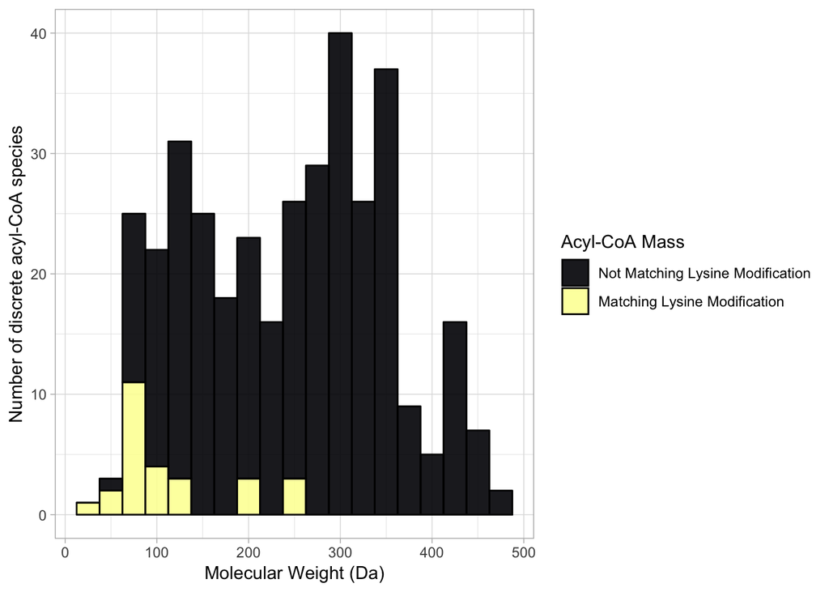

```r
ggplot(match1) +
  geom_histogram(aes(x = average_molecular_weight_noCoA, fill = mod), color = "black", binwidth = 25, center = 0, position = "stack", alpha = 0.9) +
  labs(x = "Molecular Weight (Da)", y = "Number of discrete acyl-CoA species") +
  #scale_y_continuous(limits = c(0,1)) +
  #scale_fill_manual(name="Molecular Weights of", values = cols) +
  scale_fill_viridis(discrete = TRUE, direction = 1, option = "inferno", name = "Acyl-CoA Mass", labels = c("Not Matching Lysine Modification", "Matching Lysine Modification")) +
  NULL
```

```r
#save plot
ggsave("output/fig5a.pdf", plot = last_plot(), width = 7, height = 5, dpi = 600)
```

```r
#count aldehydes
aldehyde <- metabolites %>%
  filter(str_detect(name, "aldehyde")) %>% #str_detect for aldehydes give too many false positives
  arrange(average_molecular_weight) %>%
  mutate(type = "Aldehyde") %>%
  mutate(added_carbons = str_count(smiles, "C"))

#Merge thioesters, phosphates, aldehydes
carbon <- full_join(thioester, phosphate) %>%
  full_join(aldehyde) %>%
  arrange(average_molecular_weight) %>%
  select(-c("smiles", "pre_smiles", "post_smiles", "pre_post", "normal_concentrations"))
```

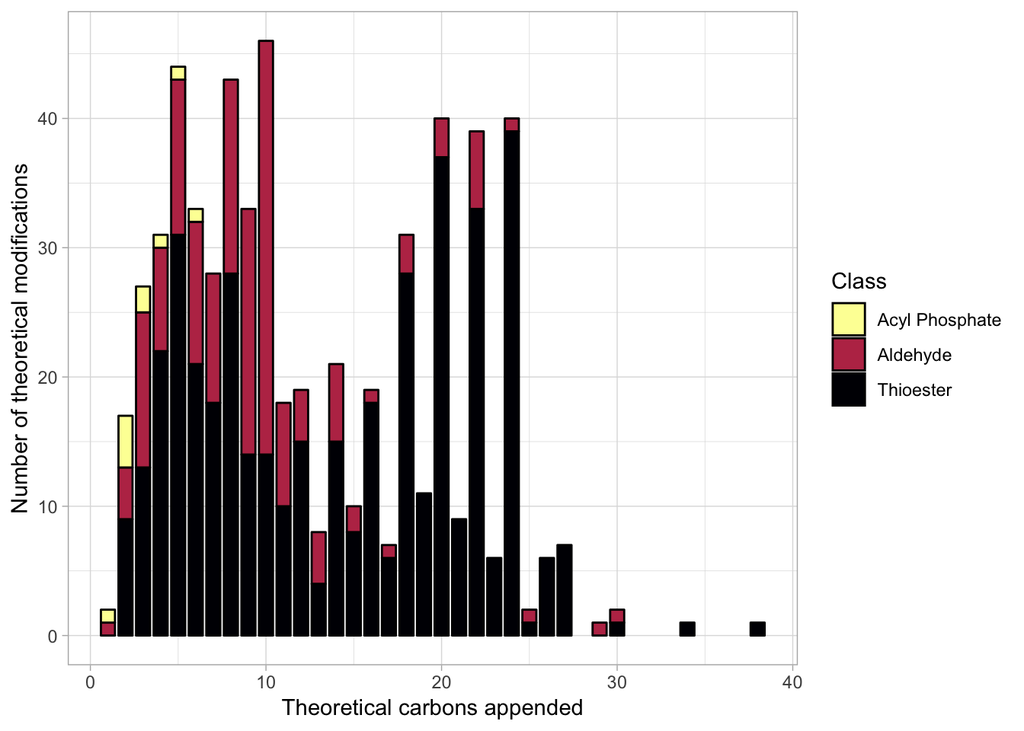

```r
ggplot(carbon) +
  geom_bar(aes(x = added_carbons, fill = type), color = "black", width = 0.8) +
  labs(x = "Theoretical carbons appended", y = "Number of theoretical modifications") +
  scale_fill_viridis(discrete = TRUE, direction = -1, option = "inferno", name = "Class") +
  NULL
```

```r
#save plot
ggsave("output/fig5b.pdf", plot = last_plot(), width = 5, height = 5, dpi = 600)
```

## Save final files

Code chunk to save files

```r
write_delim(ptm, "output/table_s1.csv", delim = ",", na = "")
write_delim(metabolites, "output/table_s2.csv", delim = ",", na = "")
write_delim(carbon, "output/table_s3.csv", delim = ",", na = "")
beep(sound = 8) #because mario is awesome
```